# PREDICTIVE ANALYTICS MSBA 6420

#### 3. SVM

```python
## Nested CV on the data

p_grid = dict (C=list(range(1,14,4)), kernel = ['rbf'], gamma = list(range(1,14,4)), probability = [True])

inner_cv = KFold(n_splits=6, shuffle=True, random_state=123)
outer_cv = KFold(n_splits=4, shuffle=True, random_state=321)
svm = SVC()

# Non_nested parameter search and scoring
svm_clf = GridSearchCV(estimator=svm, param_grid=p_grid, cv=inner_cv, scoring = 'precision')
svm_clf.fit(X_train, y_train)
print ("Best Score : ", svm_clf.best_score_)
print ("Best Estimator :", svm_clf.best_estimator_)
print ("Classification Report : \n",(classification_report(y_test,svm_clf.predict(X_test))) )

# Nested CV with parameter optimization
nested_score = cross_val_score(svm_clf.best_estimator_, X=X, y=y, cv=outer_cv)
print("Mean score after nesting : ", nested_score.mean())
```

```
Best Score :  0.9903223958863661
Best Estimator : SVC(C=1, cache_size=200, class_weight=None, coef0=0.0,
    decision_function_shape='ovr', degree=3, gamma=1, kernel='rbf', max_iter=-1,
    probability=True, random_state=None, shrinking=True, tol=0.001,
    verbose=False)
Classification Report :
               precision    recall  f1-score   support

           0       0.68      1.00      0.81       835
           1       1.00      0.27      0.42       546

    accuracy                           0.71      1381
   macro avg       0.84      0.63      0.61      1381
weighted avg       0.80      0.71      0.65      1381

Mean score after nesting :  0.7150583613492992
```

```
AUC:  0.8689357548638985
```

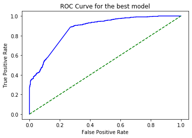

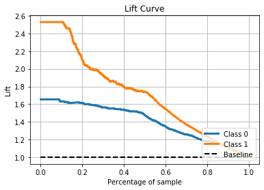

```python
# Plotted ROC curve and Lift Curves
svm_clf2 = svm_clf.best_estimator_
pred_scores = svm_clf2.fit(X_train,y_train).predict_proba(X_test)

fpr, tpr, thresh = roc_curve(y_test, pred_scores[:,1])

auc_score = auc(fpr, tpr)

plt.plot(fpr, tpr, 'blue')
plt.plot([0,1], [0,1], 'g--')
print ("AUC: ", auc_score)
#print ("FPR : ", fpr, " :: TPR : ", tpr)
plt.xlabel("False Positive Rate")
plt.ylabel("True Positive Rate")
plt.title("ROC Curve for the best model")
plt.show()
sckplt.metrics.plot_lift_curve(y_test, pred_scores)
plt.show()
```

```python
cm_svm2 = confusion_matrix(y_test, svm_clf2.predict(X_test))

print ('Confusion Matrix \n', cm_svm2)
```

```
Confusion Matrix
 [[835   0]
 [400 146]]
```

```python
cost_mat_2 = [[0,10],[1,0]]
```

```python
print (" Misclassification Cost : \n",  \
       (cm_svm2*cost_mat_2).sum())
```

```
 Misclassification Cost :
 400
```

#### 4. KNN

```python
## Nested CV on the data

p_grid = dict (n_neighbors=list(range(3,20)),
               weights = ["distance", "uniform"],
               algorithm = ["ball_tree", "kd_tree"])
inner_cv = KFold(n_splits=6, shuffle=True, random_state=123)
outer_cv = KFold(n_splits=4, shuffle=True, random_state=321)
knnc = KNC()

# Non_nested parameter search and scoring
knc_clf = GridSearchCV(estimator=knnc, param_grid=p_grid, cv=inner_cv, scoring = 'precision')
knc_clf.fit(X_train, y_train)
print ("Best Score : ", knc_clf.best_score_)
print ("Best Estimator :", knc_clf.best_estimator_)
print ("Classification Report : \n",(classification_report(y_test,log_clf.predict(X_test))) )

# Nested CV with parameter optimization
nested_score = cross_val_score(knc_clf.best_estimator_, X=X, y=y, cv=outer_cv)
print("Mean score after nesting : ", nested_score.mean())
```

```
Best Score :  0.7817062690895314
Best Estimator : KNeighborsClassifier(algorithm='ball_tree', leaf_size=30, metric='minkowski',
                     metric_params=None, n_jobs=None, n_neighbors=4, p=2,
                     weights='uniform')
Classification Report :
               precision    recall  f1-score   support

           0       0.94      0.94      0.94       835
           1       0.92      0.91      0.91       546

    accuracy                           0.93      1381
   macro avg       0.93      0.93      0.93      1381
weighted avg       0.93      0.93      0.93      1381

Mean score after nesting :  0.796567068333774
```

```
AUC:  0.8647759426202539
```

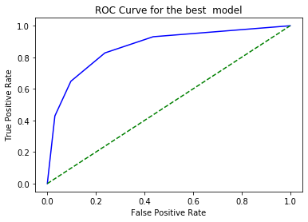

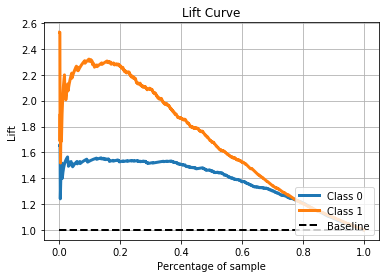

```python
# Plotted ROC curve and Lift Curves
knc_clf2 = knc_clf.best_estimator_
pred_scores = knc_clf2.fit(X_train,y_train).predict_proba(X_test)

fpr, tpr, thresh = roc_curve(y_test, pred_scores[:,1])

auc_score = auc(fpr, tpr)

plt.plot(fpr, tpr, 'blue')
plt.plot([0,1], [0,1], 'g--')
print ("AUC: ", auc_score)
#print ("FPR : ", fpr, " :: TPR : ", tpr)
plt.xlabel("False Positive Rate")
plt.ylabel("True Positive Rate")
plt.title("ROC Curve for the best  model")
plt.show()
sckplt.metrics.plot_lift_curve(y_test, pred_scores)
plt.show()
```

```python
cm_knn2 = confusion_matrix(y_test, knc_clf2.predict(X_test))

print ('Confusion Matrix \n', cm_knn2)
```

```
Confusion Matrix
 [[754  81]
 [192 354]]
```

```python
cost_mat_2 = [[0,10],[1,0]]
```

```python
print (" Misclassification Cost : \n",  \
       (cm_knn2*cost_mat_2).sum())
```

```
 Misclassification Cost :
 1002
```

#### 5. Ensemble Methods

##### Random Forest

```python
from sklearn.ensemble import RandomForestClassifier
```

```python
p_grid = dict(n_estimators = [200, 500, 1000], max_depth = list(range(3,15,3)))

inner_cv = KFold(n_splits=6, shuffle=True, random_state=123)
rfc_grid = GridSearchCV(RandomForestClassifier(), param_grid = p_grid,cv = inner_cv, scoring = 'precision')
rfc_grid.fit(X_train, y_train)
print(classification_report(y_test,rfc_grid.predict(X_test)))
```

```
              precision    recall  f1-score   support

           0       0.90      0.97      0.94       835
           1       0.95      0.83      0.89       546

    accuracy                           0.92      1381
   macro avg       0.93      0.90      0.91      1381
weighted avg       0.92      0.92      0.92      1381
```

```
AUC:  0.9712903862604462
```

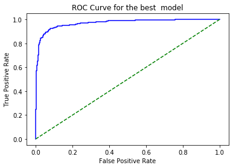

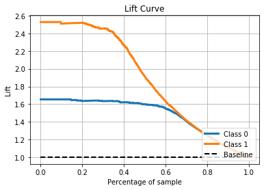

```python
# Plotted ROC curve and Lift Curves
pred_scores = rfc_grid.fit(X_train,y_train).predict_proba(X_test)


fpr, tpr, thresh = roc_curve(y_test, pred_scores[:,1])

auc_score = auc(fpr, tpr)

plt.plot(fpr, tpr, 'blue')
plt.plot([0,1], [0,1], 'g--')
print ("AUC: ", auc_score)
#print ("FPR : ", fpr, " :: TPR : ", tpr)
plt.xlabel("False Positive Rate")
plt.ylabel("True Positive Rate")
plt.title("ROC Curve for the best  model")
plt.show()
sckplt.metrics.plot_lift_curve(y_test, pred_scores)
plt.show()
```

```python
cm_rfc2 = confusion_matrix(y_test, rfc_grid.predict(X_test))

print ('Confusion Matrix \n', cm_rfc2)
```

```
Confusion Matrix
 [[811  24]
 [ 89 457]]
```

```python
cost_mat_2 = [[0,10],[1,0]]
```

```python
print (" Misclassification Cost : \n",  \
       (cm_rfc2*cost_mat_2).sum())
```

```
 Misclassification Cost :
 329
```

### Conclusions from classifcation of emails

In this problem, our task is to classify the emails into Spam or Not Spam using the 57 given attributes in 4600+ records. We first normalize the data (all columns), so that all are between 0 and 1 using a *MinMaxScaler*.

We took two approaches to determine the best performing classifiers for the email spam filtering problem. In the first case, we assumed an equal cost weight for misclassifications of Non spam into spam and vice versa. In the second case, we assigned a greater weight to the first misclassification (The False Positives) in our predictions of 10x.

This translated to looking for higher Precision model, such that we minimize the number of *False Positive* in our predictions.

The models tested to find the best predictive performance include : Decision Tree, Logistic Regression, Support Vector Machines, K-Nearest Neighbors, Ensemble Technique - Random Forest and Neural Network.

In the first approach *(Cost insensitive approach)* , we see that **Random Forest** model achieves the highest accuracy out of all the models tested with **96%**. The next best predictive performance is achieved by Logistic Regression Classifier with 92.9% accuracy, followed closely by our perceptron neural network model at 92%. KNN classifier gave the worst performance with 82% accuracy.

When we take misclassification cost into account, we find that the predictive performance follows a similar order, with **Random Forest** having the lowest misclassification cost of **56**. However, in this case, SVM appears to be performing the worst with a misclassification cost of 392 on the test data.

This leads us to believe that accuracy and the equal costed model showcase a similar behavior.

#### Part (a) Summary

**Summary Scores (Accuracy):**

- **Random Forest : 0.96**
- Logistic Regression : 0.929
- Neural Network : 0.92
- Decision Tree Classifier : 0.916
- SVM : 0.869
- KNN : 0.820

**Misclassification Cost from different models:**

- **Random Forest : 56**
- Logistic Regression : 92
- Neural Networks : 104
- Decsison Tree : 115
- KNN : 239
- SVM : 392

In the second approach *(Cost sensitive with 10:1)*, we added a 10x weight to the cost matrix achieved after the predictive modelling for each classifier and found out the misclassification cost.

A slightly strange observation is with regards to the SVM classifier, in that, it has the second lowest cost of 400, but the lowest accuracy of just 71%. Such a behavior is observed, because while optimizing the model for precision score, the SVM classifier optimized for one of the two classes (Spam = 1) and achieved a 100% Precision for filtering all those emails which are spam correctly. However, its performance drops significantly when considering the other class (Spam = 0), as it has a precision of only 68%. Therefore, we should be careful while choosing our model as SVM classifier for this kind of email filtering problem with imbalances weights.

#### Part (b) - Summary

**Misclassification Cost from different models:**

- **Random Forest : 329**
- SVM : 400
- Logistic Regression : 507
- Decsison Tree : 587
- KNN : 1002

> END